# Supplementary Data

Physiologically driven homogenization of marine ecosystems after the end-Permian mass extinction

Jood Al Aswad<sup>1*</sup>, Justin L. Penn<sup>2</sup>, Pedro Monarrez<sup>1,</sup> <sup>3</sup>, Mohamad Bazzi<sup>1</sup>, Curtis Deutsch<sup>2</sup>, Jonathan L. Payne<sup>1</sup>

<sup>1</sup> Department of Earth and Planetary Sciences, Stanford University, 450 Jane Stanford Way, Stanford, CA 94305, USA.  
<sup>2</sup> Department of Geosciences, Princeton University, Guyot Hall, Princeton, NJ 08544, USA.  
<sup>3</sup> Department of Earth, Planetary, and Space Sciences, University of Los Angeles, CA 90095, USA.

Code compiled and curated by J.A.A. and M.B. Contact and Contact

Correspondence and requests for materials should be addressed to J.A.A Contact

## Libraries

```r
rpkg <- c("dplyr ggplot2 readr boot divvy terra divDyn paleobioDB conflicted piggyback CoordinateCleaner fossilbrush rgplates icosa tidyr tibble readr purrr downloadthis ggpubr")

import_pkg <- function(x)
  x |> trimws() |> strsplit("\\s+")  |> unlist() |>
  lapply(function(x) library(x, character.only = T)) |>
  invisible()

rpkg |> import_pkg()

# Resolve conflicted functions.
conflicted::conflict_prefer(name = "filter", winner = "dplyr",losers = "stats")
```

## Custom functions

```r
#' @return calculate great circle distance in kilometers (km).
#' @param R Earth mean radius (km)
#' @param long1.r convert from degrees to radians for latitudes and longitudes.
#' @export

gcd.slc <- function(long1, lat1, long2, lat2) {
  R <- 6371
  long1.r <- long1*pi/180
  long2.r <- long2*pi/180
  lat1.r <- lat1*pi/180
  lat2.r <- lat2*pi/180
  d <- acos(sin(lat1.r)*sin(lat2.r) + cos(lat1.r)*cos(lat2.r) * cos(long2.r-long1.r)) * R
  return(d)
  }

#' @return calculate jaccard similarity coefficient
#' @param
#' @param
#' @export

jaccard_similarity <- function(x) {
  js_table <- list()
  for (k in seq_along(x)) {

  # Unique cells.
  unique_cells <- unique(x[[k]]$cell)
  jaccard_similarity_table <- data.frame(cell_x = character(), cell_y = character(), jaccard_similarity = numeric(), stringsAsFactors = F)

  for (i in 1:length(unique_cells)) {
    cell_x <- unique_cells[i]
    # Cell_x
    unique_names_cell_x <- unique(x[[k]]$accepted_name[x[[k]]$cell == cell_x])

    for (j in 1:length(unique_cells)) {
      cell_y <- unique_cells[j]

      # Duplicate comparisons.
      if (cell_x == cell_y || cell_x > cell_y) {
        next
      }

      # Cell_y
      unique_names_cell_y <- unique(x[[k]]$accepted_name[x[[k]]$cell == cell_y])
      # Intersections.
      intersection <- length(generics::intersect(unique_names_cell_x, unique_names_cell_y))
      Un <- length(generics::union(unique_names_cell_x, unique_names_cell_y))
      jaccard_similarity <- intersection/Un
      # Combine results.
      jaccard_similarity_table <- rbind(jaccard_similarity_table, data.frame(cell_x = cell_x, cell_y = cell_y, jaccard_similarity = jaccard_similarity))
    }
  }

  # Results.
  js_table[[k]] <- jaccard_similarity_table
  }
  return(js_table)
}

#' @return calculate czekanowski similarity coefficient
#' @param
#' @param
#' @export

czekanowski_similarity <- function(x) {
  2*abs(sum(x$minimum))/((sum(x$count_cell_x) + sum(x$count_cell_y)))
}

#' @return
#' @param
#' @param
#' @export

# Cross-join function.
gridComb <- function(x, cell, accepted_name) {
  cA <- expand.grid(cell = unique(x$cell), unique(x$accepted_name)) |> setNames(nm = c("cell","accepted_name"))
  return(cA)
}

#' @return
#' @param
#' @param
#' @export

# Count taxon occurrence per uqniue cell combination.
czekanowski_data_prep <- function(x, cell, accepted_name) {

  count_taxa_x <- x |>
    group_by(cell, accepted_name) |>
    summarize(count = n(), .groups = 'drop') |> rename("cell_x" = "cell", "count_cell_x" ="count")

  count_taxa_y <- x |>
    group_by(cell, accepted_name) |>
    summarize(count = n(), .groups = 'drop') |> rename("cell_y" = "cell", "count_cell_y" ="count")

  # Cell pairs.
  cell <- unique(x[[cell]])
  taxa <- unique(x[[accepted_name]])

  cell_combinations <- expand.grid(cell_x = cell, cell_y = cell,accepted_name = taxa) |>  filter(cell_x != cell_y)

  result <- cell_combinations |>
    left_join(count_taxa_x, by = c("cell_x","accepted_name"), relationship = "many-to-many") |>
    # Second join (y)
    left_join(count_taxa_y, by = c("cell_y", "accepted_name")) |>
    select("cell_x", "cell_y", "accepted_name", "count_cell_x", "count_cell_y") |>
    # Replace NA with 0
    replace_na(replace = list(count_cell_x = 0, count_cell_y = 0)) |>
    # Remove rows that at 0 in both count fields.
    filter(!(count_cell_x == 0 & count_cell_y == 0)) |>
    # Remove duplicated cell combinations
    filter(cell_x == cell_y | cell_x > cell_y) |>
    # Split by cell combination
    group_split(cell_x,cell_y)

    return(result)
}

# To calculate BC:
BC <- function(genera, localities) {
  O <- length(genera) # occs
  N <- length(unique(genera)) # genera
  L <- length(unique(localities))
  return((O-N)/((L*N)-N))
}
```

## Paleobiology Database

The fossil occurrence data analysed in this study was retrieved from the [Paleobiology Database](https://paleobiodb.org/#/) on February of 2024. Data pre-processing made use of functions from the `fossilbrush` and `CoordinateCleaner` R packages.

```r
# Read occurrence dataset.
pbdb <-
 pbdb <-read.csv(file = '~/Desktop/PT/Codes/pbdb.feb2024.csv')

# Adjust radiometric ages
interval.ma    <- pbdb |>
  group_by(early_interval) |>
 summarise(min_ma = min(min_ma))
names(interval.ma) <-c("early_interval", "interval.ma")
pbdb       <- merge(pbdb, interval.ma, by=c("early_interval"))

# Find first and last occurrences and merge back into data frame, using min_ma column
fadlad <- pbdb |>
  group_by(accepted_name)  |>
  summarise(
    fad = max(interval.ma),
    lad = min(interval.ma)
  )

# Merge fad and lad information into data frame
pbdb <- merge(pbdb, fadlad, by=c("accepted_name"))

# Add extinction/survivor binary variable
pbdb$ex <- 0
pbdb$ex[pbdb$interval.ma==pbdb$lad] <- 1

# Keep two classes and select the Induan and Changhsingian.
 pbdb <- pbdb |>
   filter(class %in% c("Gastropoda","Bivalvia"),
         interval.ma %in% c("252.17","251.2")) |>
# Identify Invalid Coordinates.
  cc_val(lat = "paleolat", lon = "paleolng")

# Use fossilbrush to clean taxonomic errors
b_ranks <- c("phylum", "class", "order", "family", "accepted_name") #accepted_name is genus name

# Define a list of suffixes to be used at each taxonomic level when scanning for synonyms
b_suff = list(NULL, NULL, NULL, NULL, c("ina", "ella", "etta"))

pbdb2 <- check_taxonomy(pbdb, suff_set = b_suff, ranks = b_ranks, verbose = FALSE,
                         clean_name = TRUE, resolve_duplicates = TRUE, jump = 5)
```

```
 + cleaning names at rank phylum
 + cleaning names at rank class
 + cleaning names at rank order
 + cleaning names at rank family
 + cleaning names at rank accepted_name
 + resolving duplicates at rank accepted_name
 + resolving duplicates at rank family
 + resolving duplicates at rank order
 + resolving duplicates at rank class
```

```r
# resolves homonyms, and jump refers to which taxonomic rank is the highest we resolve to. jump = 5 will stop before phylum since phylum level usually has little error.

# Extract PBDB data from obdb2 so we have the corrected taxa:
pbdb <- pbdb2$data[1:nrow(pbdb),]

# Select variables.
pbdb <- pbdb |>
  select(any_of(c("early_interval","interval.ma","occurrence_no","fad","lad",
                  "accepted_name","lat","long","ex","phylum","class","paleolat",
                  "paleolng","collection_no","reference_no")))
```

# Visualization of Cells and Occurrences

```r
# Get raw dataset before filtering for 20 occs
pbdb.2cha <- pbdb |> filter(interval.ma==252.17)
pbdb.2ind <- pbdb |> filter(interval.ma==251.2)

# Find raw locations for each stage:
coords.cha <- subset(pbdb.2cha, select = c(paleolng, paleolat))
coords.cha <- coords.cha |>
                          mutate_at(c('paleolng', 'paleolat'), as.numeric)
coords.ind <- subset(pbdb.2ind, select = c(paleolng, paleolat))
coords.ind <- coords.ind |>
                          mutate_at(c('paleolng', 'paleolat'), as.numeric)

# Set up the grid
hexa <-hexagrid(deg=5, sf=TRUE) #each deg = ~111 km
hexa
```

```
A/An hexagrid object with 1280 vertices, 1920 edges and 642 faces.
The mean grid edge length is 555.24 km or 4.99 degrees.
Use plot3d() to see a 3d render.
```

```r
# Find cell locations for each occurrence
cells.cha <-locate(hexa,coords.cha)
#str(cells.cha) #to see which cells have occ's
cells.ind <-locate(hexa, coords.ind)
#str(cells.ind)

# Next add cells to coords in order to match cells with their coordinates:
coords.cha$cell <- cells.cha
names(coords.cha) <- c("long", "lat", "cell")
coords.ind$cell <- cells.ind
names(coords.ind) <- c("long", "lat", "cell")

tcells.cha <- table(cells.cha) #to get no. of occupied cells
#str(tcells.cha) #get frequency of cell occ's
tcells.ind <- table(cells.ind)
#str(tcells.ind)

data.2cha <- cbind(pbdb.2cha, coords.cha) #assigns cell number for each occurrence
data.2ind <- cbind(pbdb.2ind, coords.ind)

pbdb <-rbind(data.2cha, data.2ind)
```

**Grid Plots**

Next, visualize all occurrences for each stage, using the package `rgplates` and `icosa` on R. Please note that this version requires that you have the `Gplates` software installed in your computer, as it is the most optimal version of `rgplates`.

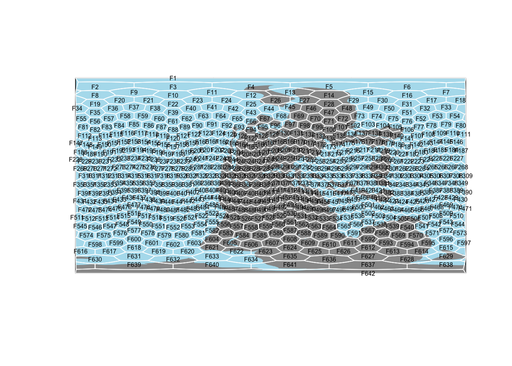

```r
# Call to Gplates offline (requires installed Gplates software)

td <-tempdir() #temporary directory
#td
rgPath <- system.file(package="rgplates")
#list.files(rgPath) #confirm that this is the correct path
unzip(file.path(rgPath, "extdata/paleomap_v3.zip"), exdir=td)
#list.files(file.path(td)) #confirm extraction has happened by looking at temporary directory
pathToPolygons <- file.path(td, "PALEOMAP_PlatePolygons.gpml") #static plate polygons
pathToRotations <- file.path(td, "PALEOMAP_PlateModel.rot")

pm <- platemodel(
  features = c("static_polygons" = pathToPolygons),
  rotation = pathToRotations
)

# Plot it out:
edge <-mapedge() #edge of the map
plates.pt<- reconstruct("static_polygons", age= 252, model =pm)
plot(edge, col = "lightblue2")
plot(plates.pt$geometry, col = "gray60", border = NA, add = TRUE)
plot(hexa,  border="white",add = TRUE)
gridlabs(hexa, cex=0.5) #get labels for each cell, labeled as spiral from North pole of grid
```

**Changhsingian occurrences**

Occurrences in the Changhsingian, with colors indicating the number of occurrences in occupied cells.

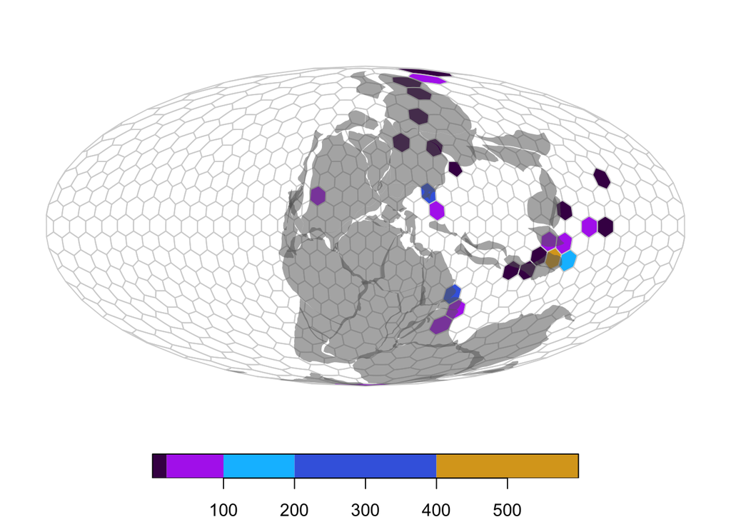

```r
#Permian:
platesMoll <- sf::st_transform(plates.pt, "ESRI:54009")
#^transform plates to Mollweide projection to plot
plot(hexa, tcells.cha,
     crs ="ESRI:54009",
     border = "lightgrey",
     pal=c("#440154ff","darkorchid2","deepskyblue","royalblue", "goldenrod"),
     breaks = c(0, 20, 100, 200, 400, 600),
     reset=FALSE)
plot(platesMoll$geometry, add = TRUE,border= NA, col = "#66666688")
```

**Induan occurrences**

Occurrences in the Induan, with colors indicating the number of occurrences in occupied cells.

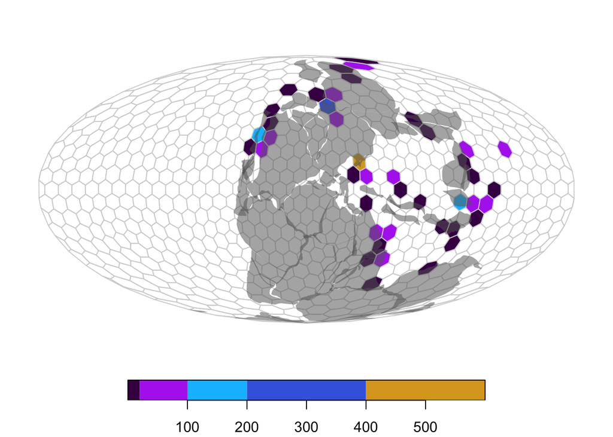

```r
#Triassic:
plot(hexa, tcells.ind,
     crs ="ESRI:54009",
     border = "lightgrey",
     pal=c("#440154ff","darkorchid2","deepskyblue","royalblue", "goldenrod"),
     breaks = c(0, 20, 100, 200, 400, 600),
     reset=FALSE)
plot(platesMoll$geometry, add = TRUE,border= NA, col = "#66666688")
```

## Biogeographic Connectedness (BC)

Here, we follow the equation from Sidor et al. 2013 to investigate changes in Biogeographic Connectedness.

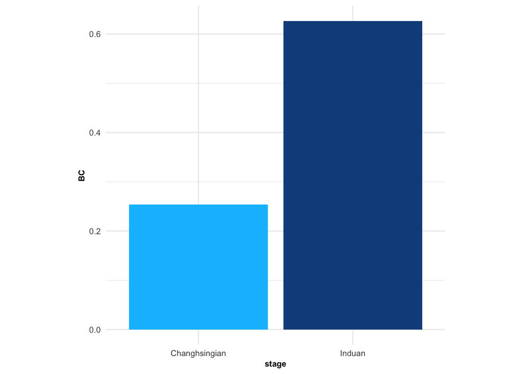

```r
# Calculate BC using the function we created earlier
bc.pt <- pbdb |>
  group_by(early_interval) |>
  summarise(
    BC = BC(accepted_name, cell),
    count_accepted_name = n(),
    count_unique_accepted_name = n_distinct(accepted_name)
  )
names(bc.pt) <- c("stage", "BC","occurrences","genera")

#Visualize:

bc.pt |>
  group_by(stage) |>
 ggplot(aes(x = stage, y = BC, fill = stage)) +
  scale_fill_manual(values =  c("deepskyblue", "dodgerblue4")) +
  scale_color_manual(values =  c("deepskyblue", "dodgerblue4")) +
  geom_bar(stat = "identity") +
theme_minimal() +
  theme(plot.title = element_text(hjust = 0.5, size = 8, face = "bold"),
        axis.title = element_text(size = 8,face = "bold"),
        axis.text = element_text(size = 8),
        strip.text = element_text(face = "bold"),
        legend.position = "none",
        aspect.ratio = 1)
```

## Data pre-processing

We investigate the data by dividing it by stage and taxonomic class. We determine the number of cells and occurrences for each stage.

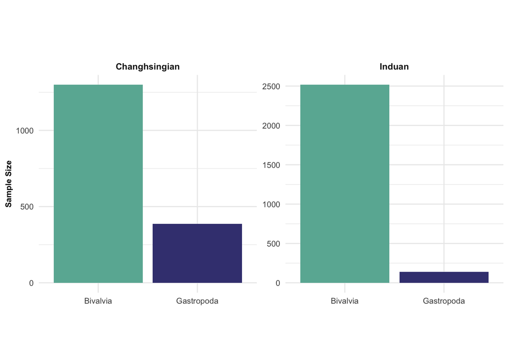

```r
# Data balance.
pbdb |>
  group_by(class,early_interval) |>
  count() |>
  ggplot(mapping = aes(x = class, y = n, fill = class)) +
  geom_bar(stat = "identity") +
  labs(x = NULL, y = "Sample Size") +
  scale_fill_manual(values =  c("#69b3a2","#404080")) +
  scale_color_manual(values = c("#69b3a2","#404080")) +
  facet_wrap(.~ early_interval, scales = "free") +
  theme_minimal() +
  theme(plot.title = element_text(hjust = 0.5, size = 8, face = "bold"),
        axis.title = element_text(size = 8,face = "bold"),
        axis.text = element_text(size = 8),
        strip.text = element_text(face = "bold"),
        legend.position = "none",
        aspect.ratio = 1)
```

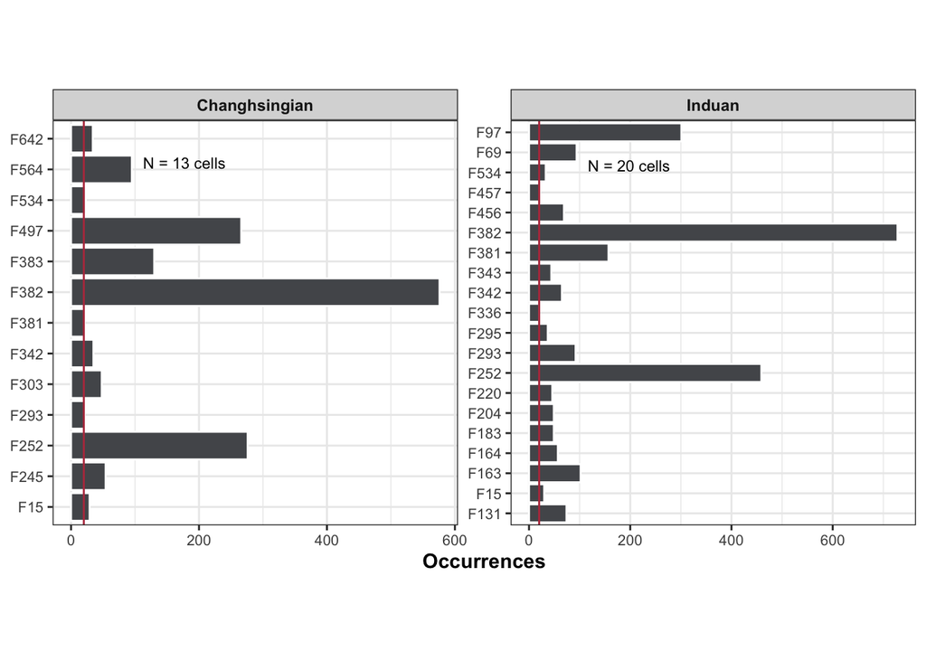

```r
# Set min occurrences
min_occ <- 20
# Changhsingian cells.
changhsingian_pbdb <-
  pbdb |>
  filter(early_interval == "Changhsingian")

changhsingian_pbdb <-
  changhsingian_pbdb |>
  # Cells.
  mutate(cell = locate(x = hexa,y = changhsingian_pbdb |> select("paleolng", "paleolat")))

# Count occurrences per cell and filter by minimum occurrence.
changhsingian_pbdb <-
  changhsingian_pbdb |>
  group_by(cell) |>
  count() |>
  setNames(nm = c("cell","occs")) |>
  inner_join(changhsingian_pbdb,by = c("cell")) |>
  filter(occs >= min_occ)

# Cell centroids.
changhsingian_centroid <-
  as.data.frame(centers(hexa))[names(table(changhsingian_pbdb$cell)),] |>
  rownames_to_column(var = "cell")

# Add centroid to master dataframe: Longitude and Latitude.
changhsingian_pbdb <-
  changhsingian_pbdb |>
  left_join(changhsingian_centroid, by = "cell")

# Induan cells
induan_pbdb <-
  pbdb |>
  filter(early_interval == "Induan")

induan_pbdb <-
  induan_pbdb |>
  # Cells.
  mutate(cell = locate(x = hexa,y = induan_pbdb |> select("paleolng", "paleolat")))

# Count occurrences per cell and filter by minimum occurrence.
induan_pbdb <-
  induan_pbdb |>
  group_by(cell) |>
  count() |>
  setNames(nm = c("cell","occs")) |>
  inner_join(induan_pbdb,by = c("cell")) |>
  filter(occs >= min_occ)

# Cell centroids
induan_centroid <-
  as.data.frame(centers(hexa))[names(table(induan_pbdb$cell)),] |>
  rownames_to_column(var = "cell")

# Add centroid coordinates to master dataframe.
induan_pbdb <-
  induan_pbdb |>
  left_join(induan_centroid, by = "cell")

# Combine the two datasets: Changhsingian & Induan.
# The pbdb dataset is has now been fully pre-processed.
pbdb <- bind_rows(changhsingian_pbdb, induan_pbdb)

# Create unique identifier for each cell.
pbdb <-
  data.frame(unique(pbdb$cell)) |>
  setNames(nm = "cell") |>
  mutate(cell_id = c(1:length(cell))) |>
  inner_join(pbdb, by = "cell")

# Plot number of occurrences per stage and cell.
cell_text <-
  data.frame(
  label = c("N = 13 cells", "N = 20 cells"),
  early_interval = c("Changhsingian", "Induan")
)

pbdb |>
  group_by(early_interval,cell) |>
  count() |>
  ggplot(mapping = aes(x = cell, y = n)) +
  geom_col(col = "white", bg = "#53565A") +
  coord_flip() +
  geom_hline(yintercept = 20, color = "#B83A4B") +
  labs(x = NULL, y = "Occurrences") +
  geom_text(data = cell_text, mapping = aes(x = c(12,18), y = 100, label = label),
            hjust   = -0.1, vjust = -0.1, size = 3) +
  facet_wrap(.~ early_interval,scales = "free",nrow = 1) +
  theme_bw() +
  theme(aspect.ratio = 1,
        axis.text  = element_text(size = 8),
        axis.title = element_text(face = "bold"),
        strip.text = element_text(face = "bold"))
```

For each stage we create individual dataframes based on the cell units and store these into separate lists.

```r
# Data splitting based on cell id and stage.
changhsingian_split <-
  pbdb |>
  filter(early_interval == "Changhsingian") |>
  group_split(cell_id) |>
  lapply(as.data.frame)

induan_split <-
  pbdb |>
  filter(early_interval == "Induan") |>
  group_split(cell_id) |>
  lapply(as.data.frame)
```

## Subsampling by cells and occurence

Here we perform subsampling without replacement on our stage-level datasets using 999 iterations. For the Changhsingian we randomly sample 20 occurrences per cell and repeated the process as stated above. Conversely, for the Induan, we applied a two-step subsampling procedure by first subsampling down to 13 cells and then by occurrences. The results are subsampled datasets (cell-specific) saved as nested objects within a larger list. These are subsequently, merged into single master dataframes (i.e., the cells) to create one single list containing 999 dataframes.

```r
# Changhsingian.
set.seed(3)

boot_changhsingian <- purrr::map(1:999, ~ { changhsingian_split |>
  # Samples rows uniformly.
  purrr::map(~ sample_n(.x, 20, replace = FALSE))
  }
)

# Induan.
set.seed(4)

boot_induan <- purrr::map(1:999, ~ { induan_split |>
  # Step 1. Cells.
  sample(13, replace = FALSE) |>
  # Step 2. Rows (i.e., occurrences).
  purrr::map(~ sample_n(.x, 20, replace = FALSE))
  }
)
```

As indicated in the previous section, we here combine cell-specific dataframes (N=13) into single joint dataframes (13*20 = 260 rows). This is repeated for all 999 sub-sampled dataframes. Worthy of note, the cells in the Induan list, will inevitably vary between the subsampled datasets, whereas, in the case of the Changhsingian they are all identical. This is because our analysis seeks to assess the impact by cell heterogeneity across geologic stages.

```r
# Changhsingian.
combined_boot_changhsingian <-
  list()

for(i in seq_along(boot_changhsingian)) {
  pC <- purrr::map_dfr(boot_changhsingian[[i]], bind_rows)
  combined_boot_changhsingian[[i]] <- pC
}

# Induan.
combined_boot_induan <-
  list()

for(i in seq_along(boot_induan)) {
  pI <- purrr::map_dfr(boot_induan[[i]], bind_rows)
  combined_boot_induan[[i]] <- pI
}
```

### Generic occurrence per cell

For each subsampled dataset in both the Induan and Changhsingian lists we here count the number of occurrence of each genera by cell. This is done for all dataframes and are then combined into one master dataframe.

```r
# Changhsingian.
ch_count_ls <-
  purrr::map(combined_boot_changhsingian, ~ .x |> group_by(cell,accepted_name) |> summarise(occs = n(), .groups = 'drop')) |>
  lapply(as.data.frame) |>
  bind_rows()

# Induan.
in_count_ls <-
  purrr::map(combined_boot_induan, ~ .x |> group_by(cell,accepted_name) |> summarise(occs = n(), .groups = 'drop')) |>
  lapply(as.data.frame) |>
  bind_rows()
```

### Unique cell pairs

```r
# Changhsingian & Induan.
cells_distinct_c <-
  tibble(unique(ch_count_ls$cell)) |> setNames(nm = "x") |>
  mutate(n_part = as.numeric(sub("F", "", x))) |>
  arrange(n_part) |>
  pull(x)

cells_distinct_i <-
  tibble(unique(in_count_ls$cell)) |> setNames(nm = "x") |>
  mutate(n_part = as.numeric(sub("F", "", x))) |>
  arrange(n_part) |>
  pull(x)

# Distinct cell pairs.
cells_distinct_pair_ch <-
  expand.grid(cells_distinct_c,cells_distinct_c,stringsAsFactors = F) |>
  setNames(nm = c("x","y")) |>
  filter(x<y) |>
  as_tibble() # 78 unique cell pairs.

cells_distinct_pair_in <-
  expand.grid(cells_distinct_i,cells_distinct_i,stringsAsFactors = F) |>
  setNames(nm = c("x","y")) |>
  filter(x<y) |>
  as_tibble() # 190 unique cell pairs.
```

### Jaccard indices

**The Jaccard similiary equation** following Miller et al., 2009

$$J(Cell X, Cell Y) = \frac{|Cell X \cap Cell Y|}{|Cell X \cup Cell Y|}$$

```r
# Changhsingian.
changhsingian_jaccard <-
  jaccard_similarity(combined_boot_changhsingian)

# Induan
induan_jaccard <-
  jaccard_similarity(combined_boot_induan)
```

```r
# Average similarity for each cell-pair and stage.

# Changhsingian.
ave_changhsingian_jaccard <-
  bind_rows(changhsingian_jaccard) |>
  group_by(cell_x, cell_y) |>
  summarise(avg_jaccard = mean(jaccard_similarity)) |>
  rename("x.cell" = "cell_x", "y.cell" = "cell_y")

# Induan
ave_induan_jaccard <-
  bind_rows(induan_jaccard) |>
  group_by(cell_x, cell_y) |>
  summarise(avg_jaccard = mean(jaccard_similarity)) |>
  rename("x.cell" = "cell_x", "y.cell" = "cell_y")
```

### Great circle distance

```r
# Changhsingian.
colnames(pbdb)[19] <- "lat"
colnames(pbdb)[20] <- "long"

changhsingian_res_matrix <- cells_distinct_pair_ch |>
  # X-coordinates
  left_join(pbdb |> select(cell,long,lat), by = c("x" = "cell"),relationship = "many-to-many") |>
  distinct(x,y,long,lat) |>
  rename("x_long" = "long","x_lat" = "lat") |>
  # Y-coordinates
  left_join(pbdb |> select(cell,long,lat), by = c("y" = "cell"),relationship = "many-to-many") |>
  distinct(x,y,x_long,x_lat,long,lat) |>
  # Rename variables.
  rename("y_long" = "long","y_lat" = "lat") |>
  # GCD.
  mutate(gcd = gcd.slc(long1 = x_long,lat1 = x_lat,long2 = y_long,lat2 = y_lat)) |>
  as.data.frame()

# Induan.
induan_res_matrix <- cells_distinct_pair_in |>
  # X-coordinates
  left_join(pbdb |> select(cell,long,lat), by = c("x" = "cell"),relationship = "many-to-many") |>
  distinct(x,y,long,lat) |>
  rename("x_long" = "long","x_lat" = "lat") |>
  # Y-coordinates
  left_join(pbdb |> select(cell,long,lat), by = c("y" = "cell"),relationship = "many-to-many") |>
  distinct(x,y,x_long,x_lat,long,lat) |>
  # Rename variables.
  rename("y_long" = "long","y_lat" = "lat") |>
  # GCD.
  mutate(gcd = gcd.slc(long1 = x_long,lat1 = x_lat,long2 = y_long,lat2 = y_lat)) |>
  as.data.frame()
```

### Czekanowski indices

**Czekanowski equation** following Miller et al., 2009

$$Czekanowski = 2 * \frac{\sum \min(x_{1k}, x_{2k})}{\sum x_{1k} + \sum x_{2k}}$$
The occurrence of a given taxa between distinct cells are evaluated against each other.

```r
# Changhsingian.
cha_combs <- gridComb(x = changhsingian_pbdb,cell = cell,accepted_name = accepted_name) # 13*221 = 2873 rows.
# Induan.
ind_combs <- gridComb(x = induan_pbdb,cell = cell,accepted_name = accepted_name) # 20*93 = 1860 rows. 190 unique cell pairs (check!)

# Next count the occurrence of genera per unique cell. This will also include genera with no occurrence in any given cell (i.e. 0).
# These are subsequently removed in the next step.
countGen <- function(combinations, age_lists) {
  purrr::map(seq_along(age_lists), function(i) {
    name_counts <-
      combinations |>
      left_join(age_lists[[i]] |>  group_by(cell, accepted_name) |> count(), by = c("cell", "accepted_name")) |>
      # Replace NA with 0.
      replace_na(list(n = 0))
    return(name_counts)
  })
}

# Changhsingian.
cha_genCell <- countGen(combinations = cha_combs ,age_lists = combined_boot_changhsingian)
# Induan.
ind_genCell <- countGen(combinations = ind_combs ,age_lists = combined_boot_induan)

# Create two identical count dataframes for each pair to join against.

# Changhsingian.
changhsingian_count_lsX <- purrr::map(cha_genCell, ~ .x |> rename("cell_x" = "cell", "count_cell_x" = "n"))
changhsingian_count_lsY <- purrr::map(cha_genCell, ~ .x |> rename("cell_y" = "cell", "count_cell_y" = "n"))
# Induan.
induan_count_lsX <- purrr::map(ind_genCell, ~ .x |> rename("cell_x" = "cell", "count_cell_x" = "n"))
induan_count_lsY <- purrr::map(ind_genCell, ~ .x |> rename("cell_y" = "cell", "count_cell_y" = "n"))

# Merge counts for each cell pair.
mCount <- function(cell_pairs, X, Y) {

  purrr::map(1:999, function(i) {
    # Rename the fields so that it matches.
    oG <-
      cell_pairs |> rename("cell_x" = "x", "cell_y" = "y") |>
      # First join (x)
      left_join(X[[i]], by = "cell_x", relationship = "many-to-many") |>
      # Second join (y)
      left_join(Y[[i]], by = c("cell_y", "accepted_name")) |>
      select("cell_x", "cell_y", "accepted_name", "count_cell_x", "count_cell_y")

    return(oG)
  })
}

# Changhsingian.
cha_joined <- mCount(cell_pairs = cells_distinct_pair_ch,X = changhsingian_count_lsX, Y = changhsingian_count_lsY)
# Induan.
ind_joined <- mCount(cell_pairs = cells_distinct_pair_in,X = induan_count_lsX, Y = induan_count_lsY)

# We then split based on distinct cell pairs. This will creates a nested list with X splits (78 for changhsingian and
# 190 for the Induan) each dataframe i.e. 999. We also remove any genera (i.e. accepted name) were 0 occurrences is recorded between cell pairs.
# This step also add a new field (the minimum field) which is based on the lowest number occurrences of a particular taxa between two cells.

czekanowski_splits <- function(joined_lists) {

  purrr::map(1:999, function(i) {
  oP <- joined_lists[[i]] |>
    # Remove
    filter(!(count_cell_x == 0 & count_cell_y == 0)) |>
    # Compute the minimum value between cell x and cell y (use count variable)
    mutate(minimum = pmin(count_cell_x, count_cell_y)) |>
    group_by(cell_x, cell_y) |>
    group_split()

  return(oP)
  })
}

cz_cha_prep <- czekanowski_splits(cha_joined)
cz_ind_prep <- czekanowski_splits(ind_joined)

# Compute the czekanowski index.
changhsingian_czekanowski <- vector(mode = "list")
for(i in seq_along(cz_cha_prep)) {
  cz <- lapply(cz_cha_prep[[i]], czekanowski_similarity)
  changhsingian_czekanowski[[i]] <- cz
}

induan_czekanowski <- vector(mode = "list")
for(i in seq_along(cz_ind_prep)) {
  czI <- lapply(cz_ind_prep[[i]], czekanowski_similarity)
  induan_czekanowski[[i]] <- czI
}

# Cell pairs.
pairs_cha <- do.call("rbind",lapply(cz_cha_prep[[1]], function(x) x[1:2][1,]))

# Find all pairs in the Induan
pairs_ind <- vector(mode = "list")

for(i in 1:999) {
  append_cells <- do.call("rbind",lapply(cz_ind_prep[[i]], function(x) x[1:2][1,]))
  pairs_ind[[i]] <- append_cells
}

# Reformat
cha_cz_results <-
  purrr::map(changhsingian_czekanowski, ~as.data.frame(unlist(.x)) |>
               rename("cz" = 1) |>
               cbind(pairs_cha) |>
               relocate(.after = "cell_y","cz") |>
               rename("x.cell" = "cell_x", "y.cell" = "cell_y")
             )

ind_cz_results <-
  purrr::map(induan_czekanowski, ~as.data.frame(unlist(.x)) |>
               rename("cz" = 1))

# Now bind the cell pairs to the Induan datasets.
ind_cz_results <- mapply(function(x, y) cbind(y, x), ind_cz_results, pairs_ind, SIMPLIFY = FALSE)

# Compute the average czekanowski per cell pair
cha_czekanowski_dataframe <- bind_rows(cha_cz_results) |> rename("cell_x" = "x.cell", "cell_y" = "y.cell")
ind_czekanowski_dataframe <- bind_rows(ind_cz_results)
```

### Results

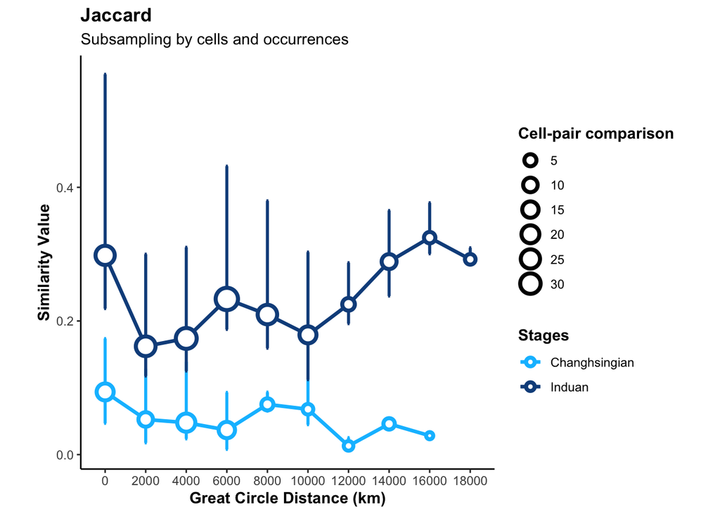

```r
# Changhsingian
changhsingian_res_matrix <-
  changhsingian_res_matrix |>
  rename("x.cell" = "x","y.cell" = "y") |>
  left_join(ave_changhsingian_jaccard,by = c("x.cell","y.cell"))

# Induan
induan_res_matrix <-
  induan_res_matrix |>
  rename("x.cell" = "x","y.cell" = "y") |>
  left_join(ave_induan_jaccard,by = c("x.cell","y.cell"))

# Bin by distance between cells (GCD in km's)
changhsingian_res_matrix$cutdist <-
  cut(changhsingian_res_matrix$gcd,
      breaks = c(0, 2000, 4000, 6000, 8000, 10000, 12000,
                 14000, 16000, 18000, 20000),
      labels = c("0", "2000", "4000", "6000","8000",
                 "10000", "12000","14000", "16000", "18000"),
                       include.lowest = TRUE)

induan_res_matrix$cutdist <-
  cut(induan_res_matrix$gcd,
      breaks = c(0, 2000, 4000, 6000, 8000, 10000, 12000,
                 14000, 16000, 18000, 20000),
      labels = c("0", "2000", "4000", "6000","8000",
                 "10000", "12000","14000", "16000", "18000"),
                       include.lowest = TRUE)

# Average and sd for Changhsingian.
sumRes_01 <-
  changhsingian_res_matrix |>
  group_by(cutdist) |>
  summarise(
    # Jaccard
    avg =  mean(avg_jaccard, na.rm = TRUE),
    sdev = sd(avg_jaccard, na.rm = TRUE),
    n = n(),
    se = sdev/sqrt(n),
    # Quantiles
    first = quantile(avg_jaccard,probs=0.25),
    second = quantile(avg_jaccard,probs=0.975)
  ) |>
  mutate(label = 'Changhsingian',label = as.factor(label)) |>
  mutate(cutdist = cutdist,
         cutdist = factor(cutdist,levels = c("0","2000","4000","6000","8000","10000","12000","14000","16000","18000","20000"))) |>
  mutate(ci = se * qt(.975, n - 1), ci = as.numeric(ci)) |>
  as.data.frame() |> suppressWarnings() # This was added to ignore the last observation.

# Average and sd for the Induan.
sumRes_02 <-
  induan_res_matrix |>
  group_by(cutdist) |>
  summarise(
    # Jaccard
    avg =  mean(avg_jaccard, na.rm = TRUE),
    sdev = sd(avg_jaccard, na.rm = TRUE),
    n = n(),
    se = sdev/sqrt(n),
     # Quantiles
    first = quantile(avg_jaccard,probs=0.25),
    second = quantile(avg_jaccard,probs=0.975)
  ) |>
  mutate(label = 'Induan',label = as.factor(label)) |>
  mutate(cutdist = cutdist,
         cutdist = factor(cutdist,levels = c("0","2000","4000","6000","8000","10000","12000","14000","16000","18000","20000"))) |>
  mutate(ci = se * qt(.975, n - 1), ci = as.numeric(ci)) |>
  as.data.frame() |> suppressWarnings() # This was added to ignore the last observation.

# Combine the two.
sumRes_03 <- bind_rows(sumRes_01,sumRes_02)

# Plot.
sumRes_03 |>
  ggplot(aes(x = cutdist, y = avg, group = label, colour = label, fill = label)) +
  geom_errorbar(aes(ymin = pmax(second), ymax=first), width=0.05,linewidth=1)+
  geom_line(linewidth = 1.2) +
  scale_size_continuous(breaks = c(5,10,15,20,25,30)) +
  geom_point(aes(size = n),shape = 21, fill = "white", stroke = 2) +
  scale_fill_manual(values =  c("deepskyblue","dodgerblue4")) +
  scale_color_manual(values = c("deepskyblue","dodgerblue4")) +
  labs(x = "Great Circle Distance (km)",
       y = "Similarity Value",
       title = "Jaccard",
       subtitle = "Subsampling by cells and occurrences", colour = "Stages", size = "Cell-pair comparison") +
  theme_classic() +
  theme(plot.title = element_text(face = "bold"),
        axis.title = element_text(face = "bold"),
        legend.title = element_text(face = "bold"),
        aspect.ratio = 1)
```

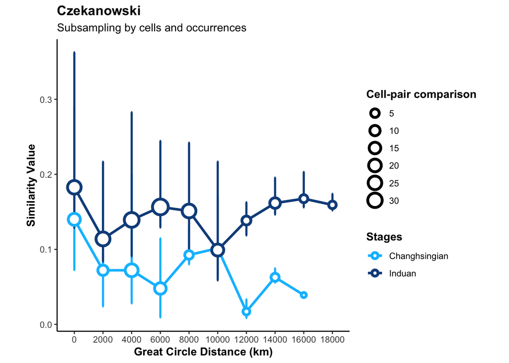

```r
# Changhsingian
changhsingian_res_matrix <-
  changhsingian_res_matrix |>
  left_join(
    cha_czekanowski_dataframe |> rename("x.cell" = "cell_x", "y.cell" = "cell_y") |>
      group_by(x.cell,y.cell) |>
      summarise(avg_cz =  mean(cz, na.rm = TRUE)), by = c("x.cell","y.cell")) |>
  relocate(.after = "avg_jaccard","avg_cz")

# Induan
induan_res_matrix <-
  induan_res_matrix |>
  left_join(
    ind_czekanowski_dataframe |> rename("x.cell" = "cell_x", "y.cell" = "cell_y") |>
      group_by(x.cell,y.cell) |>
      summarise(avg_cz =  mean(cz, na.rm = TRUE)), by = c("x.cell","y.cell")) |>
  relocate(.after = "avg_jaccard","avg_cz")

# pairs_ind <-
#   pairs_ind |>
#   bind_rows() |>
#   filter(cell_x<cell_y) |> distinct(cell_x,cell_y)


# Average and standard deviation for Changhsingian.
sumRes_04 <-
  changhsingian_res_matrix |>
  group_by(cutdist) |>
  summarise(
    avg =  mean(avg_cz, na.rm = TRUE),
    sdev = sd(avg_cz, na.rm = TRUE),
    n = n(),
    se = sdev/sqrt(n),
        # Quantiles
    first = quantile(avg_cz,probs=0.25),
    second = quantile(avg_cz,probs=0.975)
  ) |>
  mutate(label = 'Changhsingian',label = as.factor(label)) |>
  mutate(cutdist = cutdist,
         cutdist = factor(cutdist,levels = c("0","2000","4000","6000","8000","10000","12000","14000","16000","18000","20000"))) |>
  mutate(ci = se * qt(.975, n - 1), ci = as.numeric(ci)) |>
  as.data.frame() |> suppressWarnings() # This was added to ignore the last observation.

sumRes_05 <-
  induan_res_matrix |>
  group_by(cutdist) |>
  summarise(
    avg =  mean(avg_cz, na.rm = TRUE),
    sdev = sd(avg_cz, na.rm = TRUE),
    n = n(),
    se = sdev/sqrt(n),
    # Quantiles
    first = quantile(avg_cz,probs=0.25),
    second = quantile(avg_cz,probs=0.975)
  ) |>
  mutate(label = 'Induan',label = as.factor(label)) |>
  mutate(cutdist = cutdist,
         cutdist = factor(cutdist,levels = c("0","2000","4000","6000","8000","10000","12000","14000","16000","18000","20000"))) |>
  mutate(ci = se * qt(.975, n - 1), ci = as.numeric(ci)) |>
  as.data.frame() |> suppressWarnings()

sumRes_06 <- bind_rows(sumRes_04,sumRes_05)

# Plot.
sumRes_06 |>
  ggplot(aes(x = cutdist, y = avg, group = label, colour = label, fill = label)) +
  geom_errorbar(aes(ymin =second, ymax=first), width=0.05,linewidth=1)+
  geom_line(linewidth = 1.2) +
  scale_size_continuous(breaks = c(5,10,15,20,25,30)) +
  geom_point(aes(size = n),shape = 21, fill = "white", stroke = 2) +
  scale_fill_manual(values =  c("deepskyblue","dodgerblue4")) +
  scale_color_manual(values = c("deepskyblue","dodgerblue4")) +
  labs(x = "Great Circle Distance (km)",
       y = "Similarity Value",
       title = "Czekanowski",
       subtitle = "Subsampling by cells and occurrences", colour = "Stages", size = "Cell-pair comparison") +
  theme_classic() +
  theme(plot.title = element_text(face = "bold"),
        axis.title = element_text(face = "bold"),
        legend.title = element_text(face = "bold"),
        aspect.ratio = 1)
```

## Sensitivity analysis

Similarity measurements by survival status.

```r
# Retain occurrences with or greater than 15.
pbdb_sensitivity <-
  pbdb |>
  filter(occs >= 15) # 3578 observations.

# Split survival datasets by unique cell id.
sI <- pbdb_sensitivity |>
  filter(early_interval == "Induan" & ex==0 & fad >=252.17) |>
  group_split(cell_id) |> lapply(as.data.frame)

sV <- pbdb_sensitivity |>
  filter(early_interval == "Changhsingian" & ex==1) |>
  group_split(cell_id) |> lapply(as.data.frame)

# Changhsingian survivors.
sC <- pbdb_sensitivity |> filter(early_interval  == "Changhsingian" & ex==0) |>
  group_split(cell_id) |> lapply(as.data.frame)

# Subsampling.
subsampling_fun <-
  function(x, n_boot = 999, sample_size = 12, seed = 5) {
  set.seed(seed)
  # Samples.
  boot_samples <- purrr::map(1:n_boot, ~ sample(x, sample_size, replace = FALSE))
  # Combine cells into single dataframes.
  comb_samples <- purrr::map(boot_samples, ~ map_dfr(.x, bind_rows))

  return(comb_samples)
}


# Subsampled data.
sI_boot <- subsampling_fun(sI)
sV_boot <- subsampling_fun(sV)
sC_boot <- subsampling_fun(sC)
```

#### Jaccard index calculation

```r
# Induan survivors.
induan_survivors_jaccard <- jaccard_similarity(sI_boot)
# Changhsingian victims.
changhsingian_victims_jaccard <- jaccard_similarity(sV_boot)
# Changhsingian survivors.
changhsingian_survivors_jaccard <- jaccard_similarity(sC_boot)
```

**Averages**

```r
# Mean jaccard for the Induan survivors.
aIsJ <-
  bind_rows(induan_survivors_jaccard) |>
  group_by(cell_x, cell_y) |>
  summarise(avg_jaccard = mean(jaccard_similarity)) |>
  rename("x.cell" = "cell_x", "y.cell" = "cell_y")

# Mean jaccard for the Changhsingian victims.
aCvJ <-
  bind_rows(changhsingian_victims_jaccard) |>
  group_by(cell_x, cell_y) |>
  summarise(avg_jaccard = mean(jaccard_similarity)) |>
  rename("x.cell" = "cell_x", "y.cell" = "cell_y")

# Changhsingian survivors.
aCsJ <-
  bind_rows(changhsingian_survivors_jaccard) |>
  group_by(cell_x, cell_y) |>
  summarise(avg_jaccard = mean(jaccard_similarity)) |>
  rename("x.cell" = "cell_x", "y.cell" = "cell_y")
```

**Visualize results**

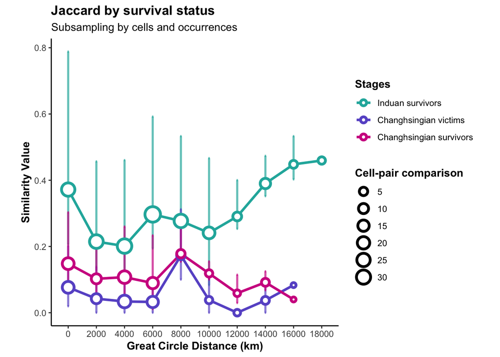

```r
# Induan results: survivors.
mRes_01 <- induan_res_matrix[,c(1:7,10)] |> left_join(aIsJ,by = c("x.cell","y.cell"))
# Changhsingian results: survivors & victims.
mRes_02 <- changhsingian_res_matrix[,c(1:7,10)] |> left_join(aCvJ,by = c("x.cell","y.cell"))
mRes_03 <- changhsingian_res_matrix[,c(1:7,10)] |> left_join(aCsJ,by = c("x.cell","y.cell"))

# Summary statistics for each survival category.

# Induan survivors.
sumRes_07 <-
  mRes_01 |>
  group_by(cutdist) |>
  summarise(
    # Jaccard
    avg =  mean(avg_jaccard, na.rm = TRUE),
    sdev = sd(avg_jaccard, na.rm = TRUE),
    n = n(),
    se = sdev/sqrt(n),
       # Quantiles
    first = quantile(avg_jaccard,probs=0.25),
    second = quantile(avg_jaccard,probs=0.975)
  ) |>
  mutate(label = 'Induan survivors',label = as.factor(label)) |>
  mutate(cutdist = cutdist,
         cutdist = factor(cutdist,levels = c("0","2000","4000","6000","8000","10000","12000","14000","16000","18000","20000"))) |>
  mutate(ci = se * qt(.975, n - 1), ci = as.numeric(ci)) |>
  as.data.frame()

# Changhsingian victims.
sumRes_08 <-
  mRes_02 |>
  group_by(cutdist) |>
  summarise(
    # Jaccard
    avg =  mean(avg_jaccard, na.rm = TRUE),
    sdev = sd(avg_jaccard, na.rm = TRUE),
    n = n(),
    se = sdev/sqrt(n),
    # Quantiles
    first = quantile(avg_jaccard,probs=0.25, na.rm=TRUE),
    second = quantile(avg_jaccard,probs=0.975, na.rm=TRUE)
  ) |>
  mutate(label = 'Changhsingian victims',label = as.factor(label)) |>
  mutate(cutdist = cutdist,
         cutdist = factor(cutdist,levels = c("0","2000","4000","6000","8000","10000","12000","14000","16000","18000","20000"))) |>
  mutate(ci = se * qt(.975, n - 1), ci = as.numeric(ci)) |>
  as.data.frame() |> suppressWarnings()

# Changhsingian survivors.
sumRes_09 <-
  mRes_03 |>
  group_by(cutdist) |>
  summarise(
    # Jaccard
    avg =  mean(avg_jaccard, na.rm = TRUE),
    sdev = sd(avg_jaccard, na.rm = TRUE),
    n = n(),
    se = sdev/sqrt(n),
       # Quantiles
    first = quantile(avg_jaccard,probs=0.25),
    second = quantile(avg_jaccard,probs=0.975)
  ) |>
  mutate(label = 'Changhsingian survivors',label = as.factor(label)) |>
  mutate(cutdist = cutdist,
         cutdist = factor(cutdist,levels = c("0","2000","4000","6000","8000","10000","12000","14000","16000","18000","20000"))) |>
  mutate(ci = se * qt(.975, n - 1), ci = as.numeric(ci)) |>
  as.data.frame() |> suppressWarnings()

# Combine all results.
sumRes_10 <- bind_rows(sumRes_07,sumRes_08,sumRes_09)

# Plot.
sumRes_10 |>
  ggplot(aes(x = cutdist, y = avg, group = label, colour = label, fill = label)) +
  geom_errorbar(aes(ymin = second, ymax = first), width=0.05,linewidth=1, alpha=0.7) +
  geom_line(linewidth = 1.2) +
  scale_size_continuous(breaks = c(5,10,15,20,25,30)) +
  geom_point(aes(size = n),shape = 21, fill = "white", stroke = 2) +
  scale_fill_manual(values =  c("lightseagreen","slateblue3", "violetred")) +
  scale_color_manual(values = c("lightseagreen","slateblue3", "violetred")) +
  labs(x = "Great Circle Distance (km)",
       y = "Similarity Value",
       title = "Jaccard by survival status",
       subtitle = "Subsampling by cells and occurrences", colour = "Stages", size = "Cell-pair comparison") +
  theme_classic() +
  theme(plot.title = element_text(face = "bold"),
        axis.title = element_text(face = "bold"),
        legend.title = element_text(face = "bold"),
        aspect.ratio = 1)
```

#### Czekanowski index calculation

**Induan survivors**

```r
# Data table
prep_Is <- map(sI_boot, ~ czekanowski_data_prep(.x, cell = "cell", accepted_name = "accepted_name"))
# Add minimum field to each data sub-list.
prep_Is <- map(prep_Is, ~ map(.x, ~ mutate(.x, minimum = pmin(count_cell_x, count_cell_y))))

# Compute czekanowski
cz_Is <- vector(mode = "list")
for(i in seq_along(prep_Is)) {
  cZ <- lapply(prep_Is[[i]],czekanowski_similarity)
  cz_Is[[i]] <- cZ
}

# Find all pairs.
sp_01 <- vector(mode = "list")
for(i in 1:999) {
  pA <- do.call("rbind",lapply(prep_Is[[i]], function(x) x[1:2][1,]))
  sp_01[[i]] <- pA
}

# Convert to dataframe and unlist.
flat_Is <- purrr::map(cz_Is, ~as.data.frame(unlist(.x)) |> rename("cz" = 1))
# Append correctly.
append_flat_Is <- mapply(function(x, y) cbind(y, x), flat_Is, sp_01, SIMPLIFY = FALSE)

# Compute the average czekanowski per cell-pair.
res_Is <- bind_rows(append_flat_Is) |> rename("x.cell" = "cell_x", "y.cell" = "cell_y")
```

**Changhsingian victims**

```r
# Data table
prep_Cv <- map(sV_boot, ~ czekanowski_data_prep(.x, cell = "cell", accepted_name = "accepted_name"))
# Add minimum field to each data sub-list.
prep_Cv <- map(prep_Cv, ~ map(.x, ~ mutate(.x, minimum = pmin(count_cell_x, count_cell_y))))

# Compute czekanowski
cz_Cv <- vector(mode = "list")
for(i in seq_along(prep_Cv)) {
  cZ <- lapply(prep_Cv[[i]],czekanowski_similarity)
  cz_Cv[[i]] <- cZ
}

# Find all pairs.
sp_02 <- vector(mode = "list")
for(i in 1:999) {
  pQ <- do.call("rbind",lapply(prep_Cv[[i]], function(x) x[1:2][1,]))
  sp_02[[i]] <- pQ
}

# Convert to dataframe and unlist.
flat_Cv <- purrr::map(cz_Cv, ~as.data.frame(unlist(.x)) |> rename("cz" = 1))
# Append correctly.
append_flat_Cv <- mapply(function(x, y) cbind(y, x), flat_Cv, sp_02, SIMPLIFY = FALSE)

# Compute the average czekanowski per cell-pair.
res_Cv <- bind_rows(append_flat_Cv) |> rename("x.cell" = "cell_x", "y.cell" = "cell_y")
```

**Changhsingian survivors**

```r
# Data table
prep_Cs <- map(sC_boot, ~ czekanowski_data_prep(.x, cell = "cell", accepted_name = "accepted_name"))
# Add minimum field to each data sub-list.
prep_Cs <- map(prep_Cs, ~ map(.x, ~ mutate(.x, minimum = pmin(count_cell_x, count_cell_y))))

# Compute czekanowski
cz_Cs <- vector(mode = "list")
for(i in seq_along(prep_Cs)) {
  cM <- lapply(prep_Cs[[i]],czekanowski_similarity)
  cz_Cs[[i]] <- cM
}

# Find all pairs.
sp_03 <- vector(mode = "list")
for(i in 1:999) {
  pO <- do.call("rbind",lapply(prep_Cs[[i]], function(x) x[1:2][1,]))
  sp_03[[i]] <- pO
}

# Convert to dataframe and unlist.
flat_Cs <- purrr::map(cz_Cs, ~as.data.frame(unlist(.x)) |> rename("cz" = 1))
# Append correctly.
append_flat_Cs <- mapply(function(x, y) cbind(y, x), flat_Cs, sp_03, SIMPLIFY = FALSE)

# Compute the average czekanowski per cell-pair.
res_Cs <- bind_rows(append_flat_Cs) |> rename("x.cell" = "cell_x", "y.cell" = "cell_y")
```

```r
# Averages.
ave_s1 <- res_Is |>
  group_by(x.cell,y.cell) |>
  summarise(avg_cz =  mean(cz, na.rm = TRUE))

ave_s2 <- res_Cv |>
  group_by(x.cell,y.cell) |>
  summarise(avg_cz =  mean(cz, na.rm = TRUE))

ave_s3 <- res_Cs |>
  group_by(x.cell,y.cell) |>
  summarise(avg_cz =  mean(cz, na.rm = TRUE))
```

**Visualize results**

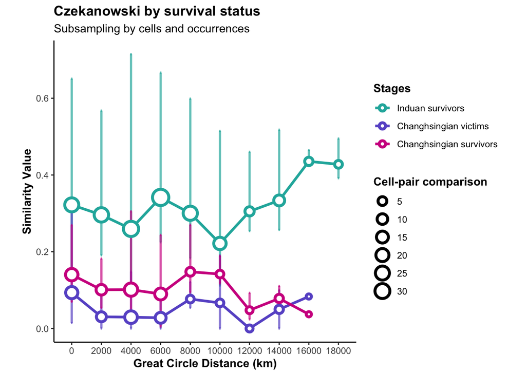

```r
# Reverse cell pairs first.
ave_s1_reversed <- ave_s1|> rename("x.cell" = "y.cell", "y.cell" = "x.cell")
ave_s2_reversed <- ave_s2|> rename("x.cell" = "y.cell", "y.cell" = "x.cell")
ave_s3_reversed <- ave_s3|> rename("x.cell" = "y.cell", "y.cell" = "x.cell")

# Induan results: survivors.
qRes_01 <- induan_res_matrix[,c(1:7,10)] |> inner_join(ave_s1_reversed, by = c("x.cell","y.cell"))
# Changhsingian results: survivors & victims.
qRes_02 <- ave_s2_reversed |>
  left_join(changhsingian_res_matrix[,c(1:7,10)],by = c("x.cell","y.cell"))

qRes_03 <- ave_s3_reversed |>
  left_join(changhsingian_res_matrix[,c(1:7,10)],by = c("x.cell","y.cell"))

# Summary statistics for each survival category.

# Induan survivors.
sumRes_11 <-
  qRes_01 |>
  group_by(cutdist) |>
  summarise(
    avg =  mean(avg_cz, na.rm = TRUE),
    sdev = sd(avg_cz, na.rm = TRUE),
    n = n(),
    se = sdev/sqrt(n),
    # quantiles
    first = quantile(avg_cz,probs=0.25),
    second = quantile(avg_cz,probs=0.975)
  ) |>
  mutate(label = 'Induan survivors',label = as.factor(label)) |>
  mutate(cutdist = cutdist,
         cutdist = factor(cutdist,levels = c("0","2000","4000","6000","8000","10000","12000","14000","16000","18000","20000"))) |>
  mutate(ci = se * qt(.975, n - 1), ci = as.numeric(ci)) |>
  as.data.frame()

# Changhsingian victims.
sumRes_12 <-
  qRes_02 |>
  group_by(cutdist) |>
  summarise(
    avg =  mean(avg_cz, na.rm = TRUE),
    sdev = sd(avg_cz, na.rm = TRUE),
    n = n(),
    se = sdev/sqrt(n),
       # Quantiles
    first = quantile(avg_cz,probs=0.25),
    second = quantile(avg_cz,probs=0.975)
  ) |>
  mutate(label = 'Changhsingian victims',label = as.factor(label)) |>
  mutate(cutdist = cutdist,
         cutdist = factor(cutdist,levels = c("0","2000","4000","6000","8000","10000","12000","14000","16000","18000","20000"))) |>
  mutate(ci = se * qt(.975, n - 1), ci = as.numeric(ci)) |>
  as.data.frame() |> suppressWarnings()

# Changhsingian survivors.
sumRes_13 <-
  qRes_03 |>
  group_by(cutdist) |>
  summarise(
    avg =  mean(avg_cz, na.rm = TRUE),
    sdev = sd(avg_cz, na.rm = TRUE),
    n = n(),
    se = sdev/sqrt(n),
       # Quantiles
    first = quantile(avg_cz,probs=0.25),
    second = quantile(avg_cz,probs=0.975)
  ) |>
  mutate(label = 'Changhsingian survivors',label = as.factor(label)) |>
  mutate(cutdist = cutdist,
         cutdist = factor(cutdist,levels = c("0","2000","4000","6000","8000","10000","12000","14000","16000","18000","20000"))) |>
  mutate(ci = se * qt(.975, n - 1), ci = as.numeric(ci)) |>
  as.data.frame() |> suppressWarnings()

# Combine all results.
sumRes_14 <- bind_rows(sumRes_11,sumRes_12,sumRes_13)

# Plot.
sumRes_14 |>
  ggplot(aes(x = cutdist, y = avg, group = label, colour = label, fill = label)) +
  geom_errorbar(aes(ymin =  second, ymax=first), width=0.05,linewidth=1, alpha=0.7) +
  geom_line(linewidth = 1.2) +
  scale_size_continuous(breaks = c(5,10,15,20,25,30)) +
  geom_point(aes(size = n),shape = 21, fill = "white", stroke = 2) +
  scale_fill_manual(values =  c("lightseagreen","slateblue3", "violetred")) +
  scale_color_manual(values = c("lightseagreen","slateblue3", "violetred")) +
  labs(x = "Great Circle Distance (km)",
       y = "Similarity Value",
       title = "Czekanowski by survival status",
       subtitle = "Subsampling by cells and occurrences", colour = "Stages", size = "Cell-pair comparison") +
  theme_classic() +
  theme(plot.title = element_text(face = "bold"),
        axis.title = element_text(face = "bold"),
        legend.title = element_text(face = "bold"),
        aspect.ratio = 1)
```

## Extra

Count occurrences per genus in the Induan to determine whether they match the disaster taxa in literature (Claraia, Eumorphotis, etc).

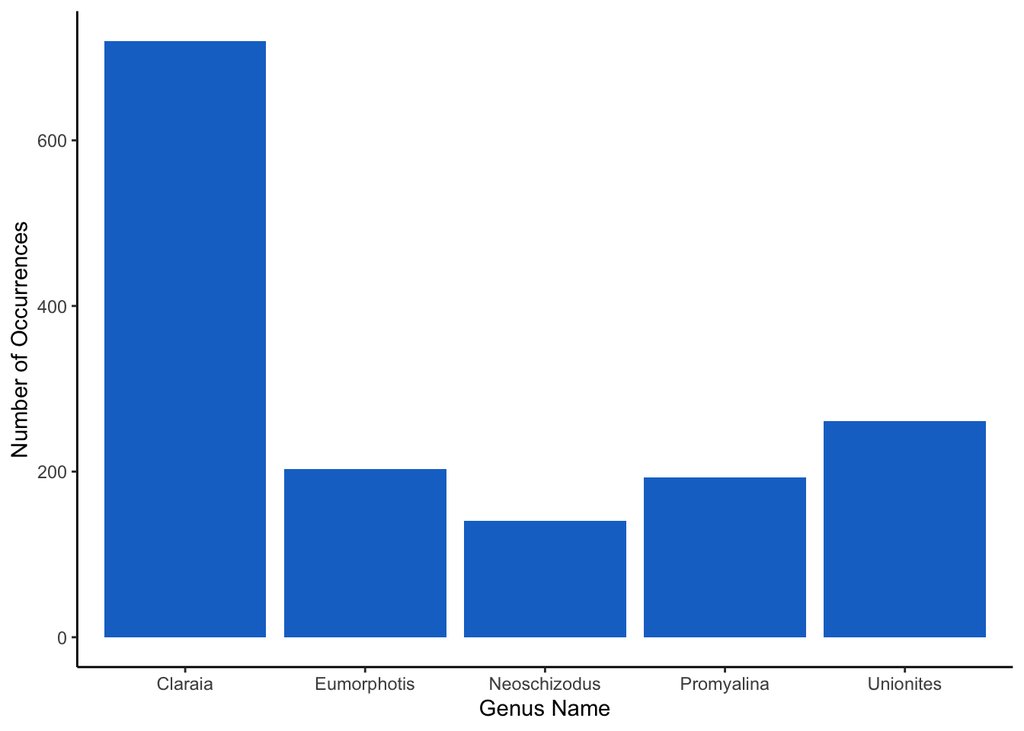

```r
# find 5 top genera based on number of occurrences
genus_counts <- pbdb.2ind  |>
                group_by(accepted_name) |>
               summarise(count = n()) |>
               top_n(5, wt = count) |>
               arrange(desc(count))

# visualize it
ggplot(genus_counts, aes(x = accepted_name, y = count)) +
  theme_classic() +
  geom_bar(stat = "identity", fill = "dodgerblue3") +
  labs(x = "Genus Name", y = "Number of Occurrences")
```